# Guessing Lengths

Alan T. Arnholt

Last knit: March 13, 2018

# 1 Problem taken from CHAPTER 2 of *A Handbook of Statistical Analyses Using R*

Shortly after metric units of length were officially introduced in Australia in the 1970s, each of a group of 44 students was asked to guess, to the nearest meter, the width of the lecture hall in which they were sitting. Another group of 69 students in the same room was asked to guess the width in feet, to the nearest foot. The data are stored in the dataset `roomwidth` of the `HSAUR3` package.

```r
library(HSAUR3)
DT::datatable(roomwidth)
```

|  | unit | width |
| --- | --- | --- |
| 1 | metres | 8 |
| 2 | metres | 9 |
| 3 | metres | 10 |
| 4 | metres | 10 |
| 5 | metres | 10 |
| 6 | metres | 10 |
| 7 | metres | 10 |
| 8 | metres | 10 |
| 9 | metres | 11 |
| 10 | metres | 11 |

[output cut: 103 more lines]

The main question is whether estimation in feet and in meters gives different results. If we convert the estimates of the room width in meters into feet by multiplying each by 3.28084 then we would like to test the hypothesis that the mean of the population of `meter` estimates is equal to the mean of the population of `feet` estimates.

Use `verbs` from `dplyr` to create a new column `estimate` that was the estimates in feet.

```r
library(tidyverse)
roomwidth <- roomwidth %>%
  mutate(estimate = ifelse(unit == "feet", 1*width, 3.28084*width))
head(roomwidth)
```

```
    unit width estimate
1 metres     8 26.24672
2 metres     9 29.52756
3 metres    10 32.80840
4 metres    10 32.80840
5 metres    10 32.80840
6 metres    10 32.80840
```

```r
tail(roomwidth)
```

```
    unit width estimate
108 feet    60       60
109 feet    63       63
110 feet    70       70
111 feet    75       75
112 feet    80       80
113 feet    94       94
```

Start by checking the assumptions required to use a two-sample *t*-test.

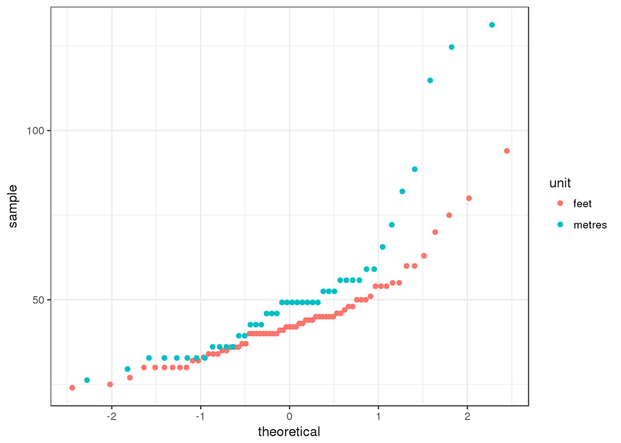

```r
ggplot(data = roomwidth, aes(sample = estimate, color = unit)) +
  stat_qq() +
  theme_bw()
```

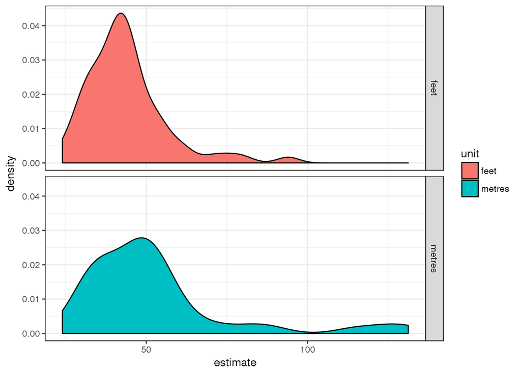

```r
ggplot(data = roomwidth, aes(x = estimate)) +
  geom_density(aes(fill = unit)) +
  theme_bw() +
  facet_grid(unit ~. )
```

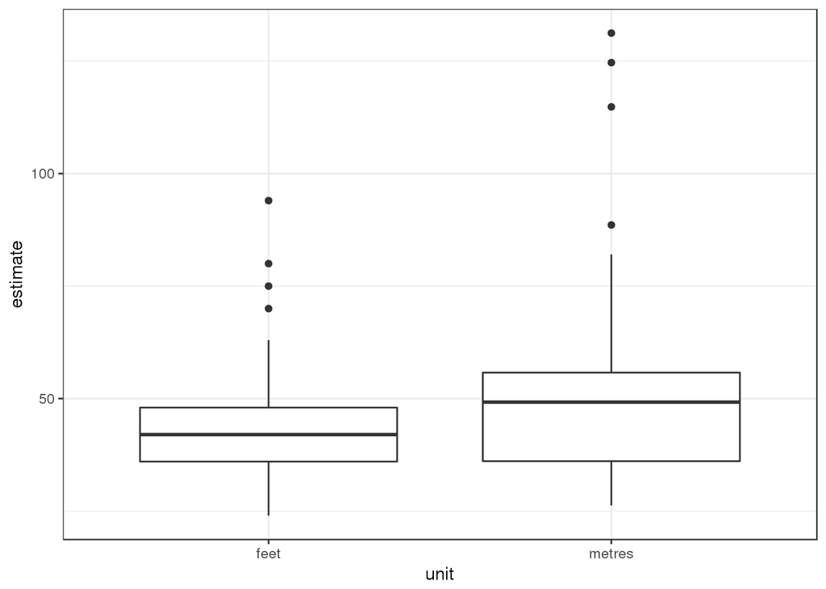

```r
ggplot(data = roomwidth, aes(x = unit, y = estimate)) +
  geom_boxplot() +
  theme_bw()
```

```r
var.test(estimate ~ unit, data = roomwidth)
```

```
    F test to compare two variances

data:  estimate by unit
F = 0.28426, num df = 68, denom df = 43, p-value = 3.584e-06
alternative hypothesis: true ratio of variances is not equal to 1
95 percent confidence interval:
 0.1618640 0.4825447
sample estimates:
ratio of variances
         0.2842555
```

## 1.1 Discussion – Should we use a *t*-test?

- Assumptions are pretty tenuous! - Not really normal based on the Q-Q plots, some outliers as well, and the variability for meter estimates is greater than the variability for feet estimates. Caution using the *t*-test! For now, we will go ahead and use a *t*-test.

## 1.2 Five-Step Procedure

1. $H_0:\mu_{feet} - \mu_{meter}=0$ versus $H_A:\mu_{feet} - \mu_{meter} \neq 0$
2. Test statistic: $\bar{X}-\bar{Y}$. The standardized test statistic $\frac{\bar{X} - \bar{Y}}{\sqrt{\tfrac{S_X^2}{n_X} + \tfrac{S_Y^2}{n_Y}}} \overset{\bullet}\sim t_{\nu}$.

```r
SA <- roomwidth %>%
  group_by(unit) %>%
  summarize(Mean = mean(estimate), SD = sd(estimate), n = n())
SA
```

```
# A tibble: 2 x 4
  unit    Mean    SD     n
  <fct>  <dbl> <dbl> <int>
1 feet    43.7  12.5    69
2 metres  52.6  23.4    44
```

3. Rejection Region

```r
t.test(estimate ~ unit, data = roomwidth, var.equal = FALSE)
```

```
    Welch Two Sample t-test

data:  estimate by unit
t = -2.3101, df = 58.78, p-value = 0.02441
alternative hypothesis: true difference in means is not equal to 0
95 percent confidence interval:
 -16.558224  -1.186481
sample estimates:
  mean in group feet mean in group metres
            43.69565             52.56800
```

```r
t_obs <- t.test(estimate ~ unit, data = roomwidth, var.equal = FALSE)$stat
t_obs
```

```
        t
-2.310073
```

```r
dof <- t.test(estimate ~ unit, data = roomwidth, var.equal = FALSE)$parameter
dof
```

```
      df
58.78029
```

```r
LRR <- qt(0.025, dof)
URR <- qt(0.975, dof)
c(LRR, URR)
```

```
[1] -2.001152  2.001152
```

The observed standardized test statistic is $t_{obs}=-2.3100732$, and the lower and upper rejection regions for a two sided alternative are -2.0011519, and 2.0011519, respectively.

4. Statistical Conclusion
1. Reject the null hypothesis since $t_{obs}=-2.3100732 < -2.0011519$.
2. Reject the null hypothesis since the *p*-value 0.024414 is less than 0.05.

```r
pvalue <- pt(t_obs, dof)*2
pvalue
```

```
         t
0.02441395
```

5. English Conclusion — There is evidence to suggest that the average estimate using feet is not the same as the average estimate (after conversion) using meters.

# 2 Other Tests

- Wilcox Test

```r
wilcox.test(estimate ~ unit, data = roomwidth)
```

```
    Wilcoxon rank sum test with continuity correction

data:  estimate by unit
W = 1145, p-value = 0.02815
alternative hypothesis: true location shift is not equal to 0
```

- Permutation Test

```r
ts <- t.test(estimate ~ unit, data = roomwidth)$stat
ts
```

```
        t
-2.310073
```

```r
B <- 10000
BT <- numeric(B)
for(i in 1:B){
  BT[i] <- t.test(estimate ~ sample(unit), data = roomwidth)$stat
}
pvalue <- mean(BT <= ts)*2
pvalue
```

```
[1] 0.015
```

# 3 Test for the Difference in Population Means When Sampling from Independent Normal Distributions with Known Variances

- $H_0:\mu_x - \mu_y = 0$ versus $H_A:\mu_x - \mu_y > 0$

Given $\sigma_x = 10$, $\sigma_y = 12$, $n_x = 10$, $n_y = 12$, and $\alpha = 0.10$, find the power of the test if $\mu_1(X, Y) = \mu_X - \mu_Y = 10$.

```r
cv <- qnorm(.90, sqrt(10^2/10 + 12^2/12))
power <- pnorm(cv, 10, sqrt(10^2/10 + 12^2/12), lower.tail = FALSE)
power
```

```
[1] 0.8047689
```

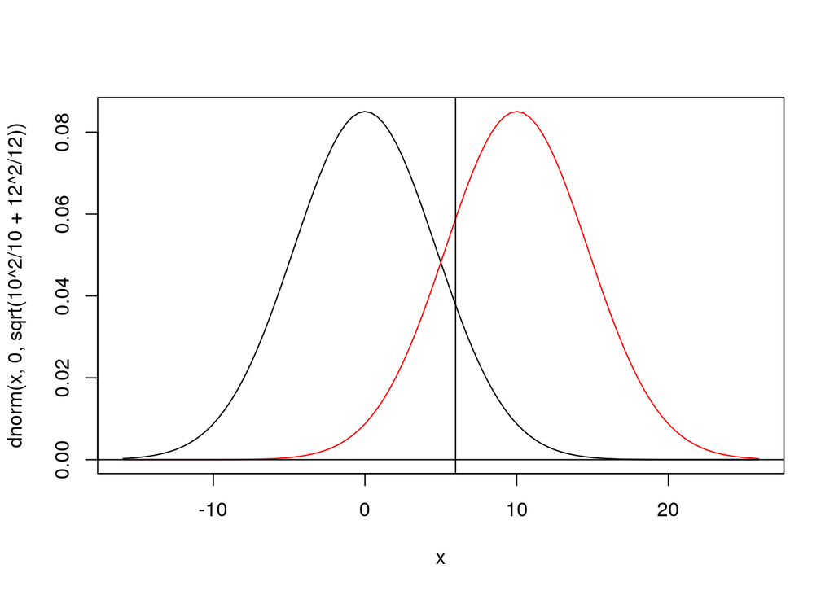

```r
# Draw this with base graphs now
curve(dnorm(x, 0, sqrt(10^2/10 + 12^2/12)), from = -3.4*sqrt(10^2/10 + 12^2/12), to = 3.4*sqrt(10^2/10 + 12^2/12) + 10)
curve(dnorm(x, 10, sqrt(10^2/10 + 12^2/12)), add = TRUE, col = "red")
abline(v = cv)
abline(h = 0)
```

## 3.1 What Happens if We Use a *t*-test?

- First compute the non-centrality parameter:

$$\gamma = \frac{\mu_1(X, Y) - \mu_0(X, Y)}{\sigma_{\bar{X}-\bar{Y}}} = \frac{(10 - 0)}{\sqrt{\frac{10^2}{10} + \frac{12^2}{12}}}= 2.1320072$$

```r
ncp <- 10/sqrt(10^2/10 + 12^2/12)
ncp
```

```
[1] 2.132007
```

```r
cv <- qt(0.90, 10 + 12 - 2)
cv
```

```
[1] 1.325341
```

```r
power <- pt(cv, 20, ncp, lower.tail = FALSE)
power
```

```
[1] 0.7898562
```

Base graphics:

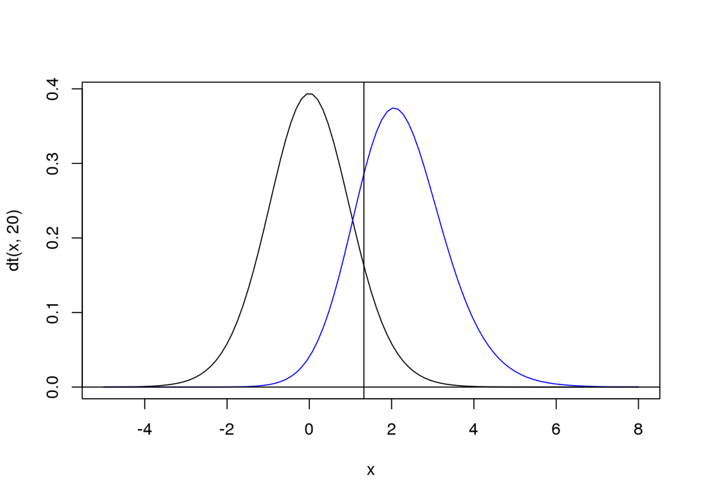

```r
curve(dt(x, 20), -5, 8)
curve(dt(x, 20, ncp), add = TRUE, col = "blue")
abline(v = cv)
abline(h = 0)
```

```r
# Estimate of nu
nu <- (10^2/10 + 12^2/12)^2 / ((10^2/10)^2/9 + (12^2/12)^2/11)
nu
```

```
[1] 19.99833
```

```r
cv1 <- qt(0.90, nu)
cv1
```

```
[1] 1.325344
```

```r
power1 <- pt(cv1, nu, ncp, lower.tail = FALSE)
power1
```

```
[1] 0.7898551
```

## 3.2 Power from `roomwidth`

- Find $\text{Power}(\mu_1(X, Y)) = 5$
- First compute the non-centrality parameter:

$$\gamma = \frac{\mu_1(X, Y) - \mu_0(X, Y)}{\sigma_{\bar{X}-\bar{Y}}} = \frac{(5 - 0)}{\sqrt{\frac{12.5^2}{69} + \frac{23.4^2}{44}}}= 1.3037006$$

```r
ncp1 <- 5/(sqrt(12.5^2/69 + 23.4^2/44))
ncp1
```

```
[1] 1.303701
```

```r
# Estimate of nu
nu1 <- (12.5^2/69 + 23.4^2/44)^2 / ((12.5^2/69)^2/68 + (23.4^2/44)^2/43)
nu1
```

```
[1] 58.84091
```

```r
cv1 <- qt(0.90, nu1)
cv1
```

```
[1] 1.296105
```

```r
power2 <- pt(cv1, nu1, ncp1, lower.tail = FALSE)
power2
```

```
[1] 0.5051956
```